# Project: Investigate the Movie Dataset

## Project Outlines

- Introduction

Introduction of the dataset and the description of two questions that I plan to explore.

- Data Wrangling

In this part, I will take steps to clean the data set and convert it to usable format. Steps to clean the data includes: 1. handle missing values; 2. handle duplicated values; 3. handle complex string features and extract usable information (feature engineering); 4. handle data types and formats;

- Exploratory Data Analysis

In this part, I will explore the clean data set with visualization, and try to answer two questions: 1. Which genres are most popular from year to year? 2. What kinds of properties are associated with movies that have high revenues?

- Conclusions

Summary of the findings and potential improvements.

## Introduction

This data set contains information about 10,000 movies collected from The Movie Database (TMDb), including user ratings and revenue.

- Certain columns, like ‘cast’ and ‘genres’, contain multiple values separated by pipe (|) characters.
- There are some odd characters in the ‘cast’ column. Don’t worry about cleaning them. You can leave them as is.
- The final two columns ending with “_adj” show the budget and revenue of the associated movie in terms of 2010 dollars, accounting for inflation over time.

The two questions I will try to answer with exploratory data analysis:

1. Which genres are most popular from year to year? In this sector, I will try to find out the 5 most popular genres over 1960-2015. Also I will take a closer look at the popular genres over each decade since 1960.
2. What kinds of properties are associated with movies that have high revenues? In this section, the specific questions I will try to tackle include:
   - How budget, vote_count and vote_average are correlated to revenue?
   - In which quarter is the movie likely to have higher revenue?
   - What genres are more likely to associated with higher revenue?
   - What are the top 5 companies that produce the highest revenue movies over 1960-2015?
   - Who are the 10 most revenue-generating directors over 1960-2015?
   - Who are the 10 most revenue-generating actors/actresses over 1960-2015?

```python
import pandas as pd
import numpy as np
import matplotlib.pyplot as plt
import seaborn as sns
```

```python
movies = pd.read_csv('../input/dataanalystnanodegree/tmdb-movies.csv')
movies.head(5)
```

|  | id | imdb_id | popularity | budget | revenue | original_title | cast | homepage | director | tagline | ... | overview | runtime | genres | production_companies | release_date | vote_count | vote_average | release_year | budget_adj | revenue_adj |
| --- | --- | --- | --- | --- | --- | --- | --- | --- | --- | --- | --- | --- | --- | --- | --- | --- | --- | --- | --- | --- | --- |
| 0 | 135397 | tt0369610 | 32.985763 | 150000000 | 1513528810 | Jurassic World | Chris Pratt\|Bryce Dallas Howard\|Irrfan Khan\|Vi... | http://www.jurassicworld.com/ | Colin Trevorrow | The park is open. | ... | Twenty-two years after the events of Jurassic ... | 124 | Action\|Adventure\|Science Fiction\|Thriller | Universal Studios\|Amblin Entertainment\|Legenda... | 6/9/15 | 5562 | 6.5 | 2015 | 1.379999e+08 | 1.392446e+09 |
| 1 | 76341 | tt1392190 | 28.419936 | 150000000 | 378436354 | Mad Max: Fury Road | Tom Hardy\|Charlize Theron\|Hugh Keays-Byrne\|Nic... | http://www.madmaxmovie.com/ | George Miller | What a Lovely Day. | ... | An apocalyptic story set in the furthest reach... | 120 | Action\|Adventure\|Science Fiction\|Thriller | Village Roadshow Pictures\|Kennedy Miller Produ... | 5/13/15 | 6185 | 7.1 | 2015 | 1.379999e+08 | 3.481613e+08 |
| 2 | 262500 | tt2908446 | 13.112507 | 110000000 | 295238201 | Insurgent | Shailene Woodley\|Theo James\|Kate Winslet\|Ansel... | http://www.thedivergentseries.movie/#insurgent | Robert Schwentke | One Choice Can Destroy You | ... | Beatrice Prior must confront her inner demons ... | 119 | Adventure\|Science Fiction\|Thriller | Summit Entertainment\|Mandeville Films\|Red Wago... | 3/18/15 | 2480 | 6.3 | 2015 | 1.012000e+08 | 2.716190e+08 |
| 3 | 140607 | tt2488496 | 11.173104 | 200000000 | 2068178225 | Star Wars: The Force Awakens | Harrison Ford\|Mark Hamill\|Carrie Fisher\|Adam D... | http://www.starwars.com/films/star-wars-episod... | J.J. Abrams | Every generation has a story. | ... | Thirty years after defeating the Galactic Empi... | 136 | Action\|Adventure\|Science Fiction\|Fantasy | Lucasfilm\|Truenorth Productions\|Bad Robot | 12/15/15 | 5292 | 7.5 | 2015 | 1.839999e+08 | 1.902723e+09 |
| 4 | 168259 | tt2820852 | 9.335014 | 190000000 | 1506249360 | Furious 7 | Vin Diesel\|Paul Walker\|Jason Statham\|Michelle ... | http://www.furious7.com/ | James Wan | Vengeance Hits Home | ... | Deckard Shaw seeks revenge against Dominic Tor... | 137 | Action\|Crime\|Thriller | Universal Pictures\|Original Film\|Media Rights ... | 4/1/15 | 2947 | 7.3 | 2015 | 1.747999e+08 | 1.385749e+09 |

5 rows × 21 columns

```python
movie_df = movies.drop(['imdb_id','homepage','runtime','tagline','overview','budget','revenue'],axis=1)
```

```python
movie_df.shape
```

```
(10866, 14)
```

```python
movie_df.info()
```

```
<class 'pandas.core.frame.DataFrame'>
RangeIndex: 10866 entries, 0 to 10865
Data columns (total 14 columns):
 #   Column                Non-Null Count  Dtype
---  ------                --------------  -----
 0   id                    10866 non-null  int64
 1   popularity            10866 non-null  float64
 2   original_title        10866 non-null  object
 3   cast                  10790 non-null  object
 4   director              10822 non-null  object
 5   keywords              9373 non-null   object
 6   genres                10843 non-null  object
 7   production_companies  9836 non-null   object
 8   release_date          10866 non-null  object
 9   vote_count            10866 non-null  int64
 10  vote_average          10866 non-null  float64
 11  release_year          10866 non-null  int64
 12  budget_adj            10866 non-null  float64
 13  revenue_adj           10866 non-null  float64
dtypes: float64(4), int64(3), object(7)
memory usage: 1.2+ MB
```

## Data Wrangling

### Part I: Missing Value

```python
# calculate the percentage of missing values in each column in the dataframe
missing_value_pct = movie_df.isnull().sum()/movie_df.shape[0]
missing_value_pct
```

```
id                      0.000000
popularity              0.000000
original_title          0.000000
cast                    0.006994
director                0.004049
keywords                0.137401
genres                  0.002117
production_companies    0.094791
release_date            0.000000
vote_count              0.000000
vote_average            0.000000
release_year            0.000000
budget_adj              0.000000
revenue_adj             0.000000
dtype: float64
```

```python
movie_df.dropna(inplace=True)
# to check if all rows with missing value have been removed
movie_df.isnull().sum()/movie_df.shape[0]
```

```
id                      0.0
popularity              0.0
original_title          0.0
cast                    0.0
director                0.0
keywords                0.0
genres                  0.0
production_companies    0.0
release_date            0.0
vote_count              0.0
vote_average            0.0
release_year            0.0
budget_adj              0.0
revenue_adj             0.0
dtype: float64
```

```python
movie_df.shape
```

```
(8667, 14)
```

### Part II: Duplicates

```python
# check if there are any duplicated records and how many
movie_df.duplicated().sum()
```

```
1
```

```python
# delte the duplicated row
movie_df.drop_duplicates(inplace=True)
```

### Part III: Complicated String Features

```python
string_feats = ['cast','director','keywords','genres','production_companies']
movie_df[string_feats].head(3)
```

|  | cast | director | keywords | genres | production_companies |
| --- | --- | --- | --- | --- | --- |
| 0 | Chris Pratt\|Bryce Dallas Howard\|Irrfan Khan\|Vi... | Colin Trevorrow | monster\|dna\|tyrannosaurus rex\|velociraptor\|island | Action\|Adventure\|Science Fiction\|Thriller | Universal Studios\|Amblin Entertainment\|Legenda... |
| 1 | Tom Hardy\|Charlize Theron\|Hugh Keays-Byrne\|Nic... | George Miller | future\|chase\|post-apocalyptic\|dystopia\|australia | Action\|Adventure\|Science Fiction\|Thriller | Village Roadshow Pictures\|Kennedy Miller Produ... |
| 2 | Shailene Woodley\|Theo James\|Kate Winslet\|Ansel... | Robert Schwentke | based on novel\|revolution\|dystopia\|sequel\|dyst... | Adventure\|Science Fiction\|Thriller | Summit Entertainment\|Mandeville Films\|Red Wago... |

As can be seen from the above, there are usually more than one values in fields cast, keywords, genres, and production_companies. And the number of values are not necessarily the same across different rows under the same column. Additionally, the values in column director are composed of multiple words, instead of one single string value. The idea here is that, for columns with more than one values, pick up the most important values from each column, assuming the most important values are the ones that appear first in column. For columns with one value that is composed of multiple words, combine the words into one single string so it can be used in analysis later.

First I will process column production_companies. For this column, I will only pick up the first listed production company assuming it's the primary and most important one.

```python
# Since values in production_companies are separated by pipe (|) character, we can use '|' to split values
movie_df['production_companies'] = movie_df['production_companies'].apply(lambda x: x.split('|')[0])
```

```python
# there are 2649 unique values in the column after the process
movie_df['production_companies'].nunique()
```

```
2649
```

Next I will process columns cast, keywords, and genres. For these columns, I will pick top 3 values for each column and save them to a list. Unlike production company, one single value in each of the three fiends probably won't be sufficient to describe a movie. Thus we need to extract three values for each field. Again, I assume the first 3 listed values will be the most important values.

```python
# define a function get_list to extract the first 3 values in a given column
def get_list(x):
    values = x.split('|')
    if len(values) > 3:
        values = values[:3]
    return values
```

```python
feats = ['cast','keywords','genres']
for feat in feats:
    movie_df[feat] = movie_df[feat].apply(get_list)
# check if the above columns as properly processed
movie_df[feats].head(3)
```

|  | cast | keywords | genres |
| --- | --- | --- | --- |
| 0 | [Chris Pratt, Bryce Dallas Howard, Irrfan Khan] | [monster, dna, tyrannosaurus rex] | [Action, Adventure, Science Fiction] |
| 1 | [Tom Hardy, Charlize Theron, Hugh Keays-Byrne] | [future, chase, post-apocalyptic] | [Action, Adventure, Science Fiction] |
| 2 | [Shailene Woodley, Theo James, Kate Winslet] | [based on novel, revolution, dystopia] | [Adventure, Science Fiction, Thriller] |

Next I will convert all the string values in each column to lower case. I define a function get_lower_case to convert string values. This function handles scenario when a column contains a list and when a column contaisn only a string. Additionally, this function will get rid of the space between words if these words belong to a name or a phrase. For example, it will convert 'Tom Hardy' to 'tomhardy', and convert 'Science Fiction' to 'sciencefiction'.

```python
def get_lower_case(x):
    if isinstance(x,list):
        return [str.lower(i.replace(' ','')) for i in x]
    else:
        if isinstance(x,str):
            return str.lower(x.replace(' ',''))
        else:
            return ''
```

```python
# iterate over the column names saved in string_feats earlier, and convert string values to lower case
for feat in string_feats:
    movie_df[feat] = movie_df[feat].apply(get_lower_case)
movie_df.head(3)
```

|  | id | popularity | original_title | cast | director | keywords | genres | production_companies | release_date | vote_count | vote_average | release_year | budget_adj | revenue_adj |
| --- | --- | --- | --- | --- | --- | --- | --- | --- | --- | --- | --- | --- | --- | --- |
| 0 | 135397 | 32.985763 | Jurassic World | [chrispratt, brycedallashoward, irrfankhan] | colintrevorrow | [monster, dna, tyrannosaurusrex] | [action, adventure, sciencefiction] | universalstudios | 6/9/15 | 5562 | 6.5 | 2015 | 1.379999e+08 | 1.392446e+09 |
| 1 | 76341 | 28.419936 | Mad Max: Fury Road | [tomhardy, charlizetheron, hughkeays-byrne] | georgemiller | [future, chase, post-apocalyptic] | [action, adventure, sciencefiction] | villageroadshowpictures | 5/13/15 | 6185 | 7.1 | 2015 | 1.379999e+08 | 3.481613e+08 |
| 2 | 262500 | 13.112507 | Insurgent | [shailenewoodley, theojames, katewinslet] | robertschwentke | [basedonnovel, revolution, dystopia] | [adventure, sciencefiction, thriller] | summitentertainment | 3/18/15 | 2480 | 6.3 | 2015 | 1.012000e+08 | 2.716190e+08 |

### Part IV: Data Type and Data Format

```python
movie_df.dtypes
```

```
id                        int64
popularity              float64
original_title           object
cast                     object
director                 object
keywords                 object
genres                   object
production_companies     object
release_date             object
vote_count                int64
vote_average            float64
release_year              int64
budget_adj              float64
revenue_adj             float64
dtype: object
```

Everything else looks good except for column release_date. It should be a datatime column. However, this column is somewhat irrelevant to the questions I'm trying to answer here, so probably I can drop this column. Before I do that, I'd like to extract a new field from this column: the season or the quarter in which the movie is released. And I define the relation like this:

> - Q1: if month number is 1, 2, 3;
> - Q2: if month number is 4, 5, 6
> - Q3: if month number is 7, 8, 9
> - Q4: if month number is 10, 11, 12

```python
def find_quarter(x):
    month = x.split('/')[0]
    if month in ['1','2','3']:
        quarter = 'Q1'
    elif month in ['4','5','6']:
        quarter = 'Q2'
    elif month in ['7','8','9']:
        quarter = 'Q3'
    else:
        quarter = 'Q4'
    return quarter
```

```python
movie_df['release_quarter'] = movie_df['release_date'].apply(find_quarter)
movie_df.drop(['release_date'],axis=1,inplace=True)
```

```python
movie_df.info()
```

```
<class 'pandas.core.frame.DataFrame'>
Int64Index: 8666 entries, 0 to 10865
Data columns (total 14 columns):
 #   Column                Non-Null Count  Dtype
---  ------                --------------  -----
 0   id                    8666 non-null   int64
 1   popularity            8666 non-null   float64
 2   original_title        8666 non-null   object
 3   cast                  8666 non-null   object
 4   director              8666 non-null   object
 5   keywords              8666 non-null   object
 6   genres                8666 non-null   object
 7   production_companies  8666 non-null   object
 8   vote_count            8666 non-null   int64
 9   vote_average          8666 non-null   float64
 10  release_year          8666 non-null   int64
 11  budget_adj            8666 non-null   float64
 12  revenue_adj           8666 non-null   float64
 13  release_quarter       8666 non-null   object
dtypes: float64(4), int64(3), object(7)
memory usage: 1015.5+ KB
```

So far things look to be in good shape. I will move forward and start exploratory data analysis using the pre-processed data.

## Exploratory Data Analysis

This part I will try to answer the questions brought up during project introduction.

### Question 1: Which genres are most popular from year to year?

#### Q 1.1 What are the 5 most popular genres over 1960-2015?

For the genres column I extracted three different values for each row. I will count all of these values into the genres frequency. I will first create a sub-dataframe containing only columns release_year and genres, create a separate column for each of the genre value, and then melt the sub-dataframe into a 2-column dataframe again.

```python
# create a sub-dataframe containing only columns release_year, genres and revenue_adj. Column revenue_adj is for later use
df_genre = movie_df[['release_year','genres','revenue_adj']]

# create separate column for each genre value
df_genre['genres1'] = df_genre['genres'].apply(lambda x: x[0])
df_genre['genres2'] = df_genre['genres'].apply(lambda x: x[1] if len(x)>1 else None)
df_genre['genres3'] = df_genre['genres'].apply(lambda x: x[2] if len(x)>2 else None)
# remove original column genres, and melt 4-column dataframe into 2-column dataframe
df_genre = df_genre.drop('genres',axis=1).melt(['release_year','revenue_adj']).drop('variable',axis=1).rename(columns={'value':'genres'})
df_genre.head(3)
```

|  | release_year | revenue_adj | genres |
| --- | --- | --- | --- |
| 0 | 2015 | 1.392446e+09 | action |
| 1 | 2015 | 3.481613e+08 | action |
| 2 | 2015 | 2.716190e+08 | adventure |

```python
df_genre.shape
```

```
(25998, 3)
```

```python
# group the dataframe by genres and release_year, and count the frequency of different genre over each year
genres_count = df_genre.groupby(['genres','release_year']).size().reset_index(name='counts')
# pivot the grouped dataframe so each row represents a year and each column represents a genre value
genres_count = genres_count.pivot(index='release_year', columns='genres', values='counts')
genres_count.head(3)
```

| genres release_year | action | adventure | animation | comedy | crime | documentary | drama | family | fantasy | foreign | history | horror | music | mystery | romance | sciencefiction | thriller | tvmovie | war | western |
| --- | --- | --- | --- | --- | --- | --- | --- | --- | --- | --- | --- | --- | --- | --- | --- | --- | --- | --- | --- | --- |
| 1960 | 7.0 | 5.0 | NaN | 7.0 | 1.0 | NaN | 12.0 | 3.0 | 2.0 | NaN | 3.0 | 7.0 | 1.0 | NaN | 4.0 | 2.0 | 6.0 | NaN | NaN | 4.0 |
| 1961 | 7.0 | 5.0 | 1.0 | 7.0 | 2.0 | NaN | 16.0 | 2.0 | 1.0 | NaN | 3.0 | 3.0 | 2.0 | 1.0 | 5.0 | 2.0 | NaN | NaN | NaN | 3.0 |
| 1962 | 6.0 | 7.0 | NaN | 5.0 | 3.0 | NaN | 18.0 | 1.0 | 1.0 | NaN | 3.0 | 5.0 | 1.0 | 3.0 | 3.0 | 2.0 | 7.0 | NaN | NaN | 3.0 |

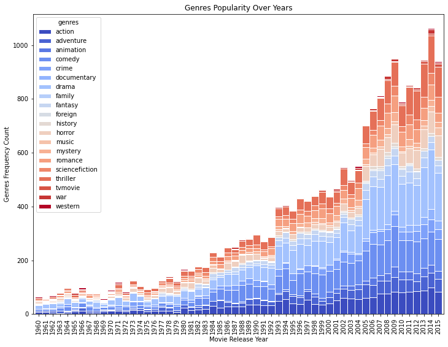

```python
genres_count.plot(kind='bar',stacked=True,figsize=(12,9),cmap='coolwarm',edgecolor='white',width=1)
plt.title('Genres Popularity Over Years')
plt.xlabel('Movie Release Year')
plt.ylabel('Genres Frequency Count')
```

The above graph shows the over years, the 5 most popular genres are action, comedy, drama, horror, and thriller. I will pick up the 5 genren and show the trends in a line plot per below. Basically you can tell the trend shows that what's popular most likely has always been popular.

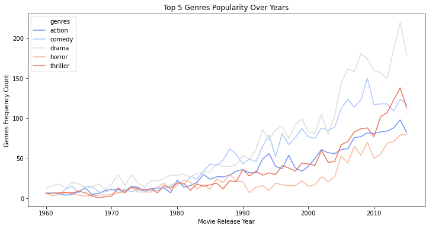

```python
plt.figure(figsize=(12,6))
sns.lineplot('release_year','counts',hue='genres',palette='coolwarm',data=df_genre.groupby(['genres','release_year']).size().reset_index(name='counts').query('genres in ["action","drama","comedy","thriller","horror"]'))

plt.title('Top 5 Genres Popularity Over Years')
plt.xlabel('Movie Release Year')
plt.ylabel('Genres Frequency Count')
```

#### Q1.2 What are the popular genres over each decade since 1960?

First I will add a new column "decades" to the dataframe df_genre. And then I will display the top 3 genres over each decade in a bar chart.

```python
# use pandas function .cut() to segregate release_year into each decade
bin_edge = [1960, 1970, 1980, 1990, 2000, 2010, 2015]
bin_name = ['1960s','1970s','1980s','1990s','2000s','2010s']
df_genre['decades'] = pd.cut(df_genre['release_year'],bins=bin_edge,labels=bin_name)
```

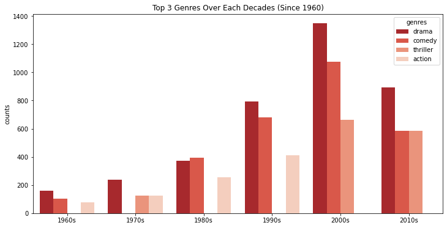

```python
genres_decade = df_genre.groupby(['decades','genres']).size().reset_index(name='counts').sort_values(by='counts',ascending=False)
genres_decade = genres_decade.sort_values(by=['decades','counts'],ascending=[False,False]).groupby('decades').head(3)

plt.figure(figsize=(12,6))
sns.barplot(x='decades',y='counts',hue='genres',data=genres_decade,palette='Reds_r')
plt.title('Top 3 Genres Over Each Decades (Since 1960)')
plt.xlabel('')
```

From the above we can see drama has always been the most popular genre except over 1980s, when the most popular genre became comedy.

### Question 2: What kinds of properties are associated with movies that have high revenues?

#### Q2.1 How budget, popularity, vote_count and vote_average are correlated to revenue?

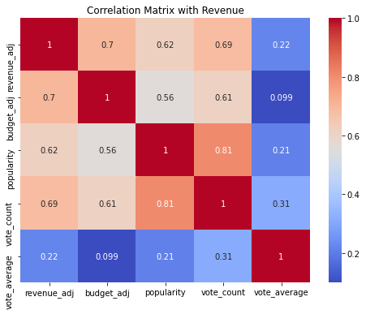

```python
corr = movie_df[['revenue_adj','budget_adj','popularity','vote_count','vote_average']].corr(method='spearman')

plt.figure(figsize=(8,6))
sns.heatmap(corr,xticklabels=corr.columns,yticklabels=corr.columns,annot=True,cmap='coolwarm')
plt.title('Correlation Matrix with Revenue')
```

The correlation matrix shows that all four numeric features have positive correlation with revenue. Buedget, vote count and popularity have relatively strong correlation with revenue, while vote average has much weaker correlation with revenue. Below shows the joint distribution between revenue and each of the four numeric features. We can tell that a big budget movie will likely generate high revenue. If a movie is tagged as popular and many people provide voting for the movie, the revenue of the movie is also likely to be relatively high. On the other hand, if a movie has a high average voting rate, it doesn't necessarily mean that the movie will achive high revenue, maybe because sometimes the movie is only successful among a very limited of target audience with unique taste.

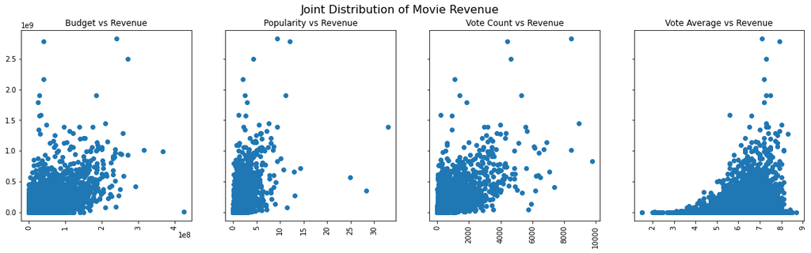

```python
fig,axes = plt.subplots(nrows=1,ncols=4,sharey=True,figsize=(20,5))
fig.suptitle('Joint Distribution of Movie Revenue', fontsize=16)
for ax in fig.axes:
    plt.sca(ax)
    plt.xticks(rotation=90)
axes[0].scatter(x='budget_adj',y='revenue_adj',data=movie_df)
axes[0].set_title('Budget vs Revenue')
axes[1].scatter(x='popularity',y='revenue_adj',data=movie_df)
axes[1].set_title('Popularity vs Revenue')
axes[2].scatter(x='vote_count',y='revenue_adj',data=movie_df)
axes[2].set_title('Vote Count vs Revenue')
axes[3].scatter(x='vote_average',y='revenue_adj',data=movie_df)
axes[3].set_title('Vote Average vs Revenue')
```

#### Q2.2 In which quarter is the movie likely to have higher revenue?

```python
movie_df[movie_df['revenue_adj']>0].groupby('release_quarter')['revenue_adj'].describe()
```

| release_quarter | count | mean | std | min | 25% | 50% | 75% | max |
| --- | --- | --- | --- | --- | --- | --- | --- | --- |
| Q1 | 929.0 | 8.664650e+07 | 1.671436e+08 | 10.000000 | 1.198461e+07 | 3.910921e+07 | 9.678616e+07 | 2.789712e+09 |
| Q2 | 1050.0 | 1.644706e+08 | 2.458958e+08 | 14.733479 | 1.713435e+07 | 6.450178e+07 | 2.072651e+08 | 1.907006e+09 |
| Q3 | 1316.0 | 9.107489e+07 | 1.505110e+08 | 6.951084 | 8.612733e+06 | 3.555807e+07 | 1.040260e+08 | 1.583050e+09 |
| Q4 | 1241.0 | 1.436953e+08 | 2.269583e+08 | 2.861934 | 1.933067e+07 | 6.882570e+07 | 1.761638e+08 | 2.827124e+09 |

From the descriptive statistics of movie revenue data over each quarter, we can tell that Q3 and Q4 have the most number of movies released which might be due to that movie producers hope to occupy the idle time of great amount of audience during summer vacation and holiday seasons at year end. However movies released during Q3 don't necessarily have high revenue. Instead, Q1 and Q4 have the highest maximum revenue, while Q2 and Q4 have relatively high average revenue and median revenue. So to summarize, if a movie is release in Q4, statistically it's more likely to have high revenue.

#### Q2.3 What genres are more likely to associated with higher revenue?

I will use the dataframe df_genre saved from question 1 and add two aggregation columns revenue_avg and revenue_total. Then save the new aggregation columns as well as column genres to a new dataframe df_rev.

```python
df_rev = df_genre.drop('release_year',axis=1).groupby('genres')['revenue_adj'].agg([('revenue_avg','mean'),('revenue_total','sum')])
```

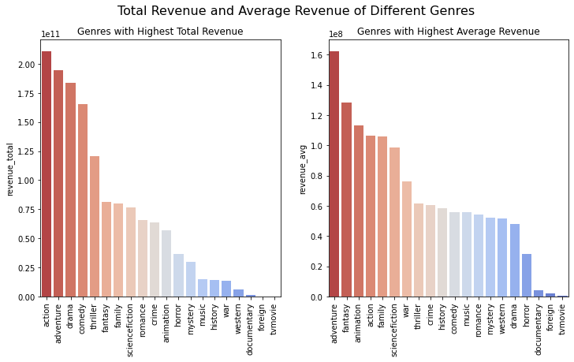

```python
fig,axes = plt.subplots(nrows=1,ncols=2,sharey=False,figsize=(12,6))
fig.suptitle('Total Revenue and Average Revenue of Different Genres', fontsize=16)
for ax in fig.axes:
    plt.sca(ax)
    plt.xticks(rotation=90)
sns.barplot(ax=axes[0],x=df_rev.sort_values(by='revenue_total',ascending=False).index,y='revenue_total',data=df_rev.sort_values(by='revenue_total',ascending=False),palette='coolwarm_r')
axes[0].set_title('Genres with Highest Total Revenue')
axes[0].set_xlabel('')
sns.barplot(ax=axes[1],x=df_rev.sort_values(by='revenue_avg',ascending=False).index,y='revenue_avg',data=df_rev.sort_values(by='revenue_avg',ascending=False),palette='coolwarm_r')
axes[1].set_title('Genres with Highest Average Revenue')
axes[1].set_xlabel('')
```

From the above we can tell that the top 5 genres with the highest total revenue contributions are action, adventure, drama, comedy and thriller. And the top 5 genres with the highest average revenue are adventure, fantasy, animation, action adn family.

#### Q2.4 What are the top 5 companies that produce the highest revenue movies over 1960-2015?

```python
df_prod = movie_df[['production_companies','revenue_adj']].groupby('production_companies')['revenue_adj'].agg([('revenue_avg','mean'),('revenue_total','sum')])
```

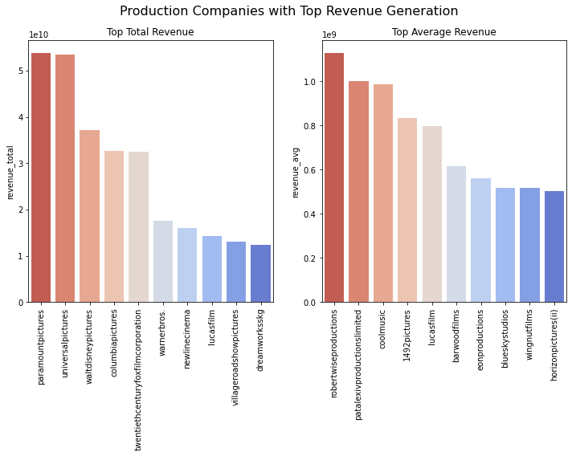

```python
fig,axes = plt.subplots(nrows=1,ncols=2,sharey=False,figsize=(12,6))
fig.suptitle('Production Companies with Top Revenue Generation', fontsize=16)
for ax in fig.axes:
    plt.sca(ax)
    plt.xticks(rotation=90)
sns.barplot(ax=axes[0],x=df_prod.sort_values(by='revenue_total',ascending=False)[:10].index,y='revenue_total',data=df_prod.sort_values(by='revenue_total',ascending=False)[:10],palette='coolwarm_r')
axes[0].set_title('Top Total Revenue')
axes[0].set_xlabel('')
sns.barplot(ax=axes[1],x=df_prod.sort_values(by='revenue_avg',ascending=False)[:10].index,y='revenue_avg',data=df_prod.sort_values(by='revenue_avg',ascending=False)[:10],palette='coolwarm_r')
axes[1].set_title('Top Average Revenue')
axes[1].set_xlabel('')
```

The top 5 production companies with top revenue generation ability are Paramount Pictures, Universal Pictures, Walt Disney Pictures, Columbia Pictures, and Twentieth Century Fox Film Corporation. This finding aligns with my general impression that those companies are the most famous production and distribution companies. We can see from the visualization that these 5 companies' revenue generation ability are far more superior than the rest of the companies.

```python
movie_df.query('production_companies in ["robertwiseproductions","patalexivproductionslimited","coolmusic","1492pictures","lucasfilm"]')[['production_companies','original_title','revenue_adj','budget_adj','vote_average']].sort_values(by='revenue_adj',ascending=False).groupby(['production_companies']).first()
```

| production_companies | original_title | revenue_adj | budget_adj | vote_average |
| --- | --- | --- | --- | --- |
| 1492pictures | Harry Potter and the Philosopher's Stone | 1.202518e+09 | 1.539360e+08 | 7.2 |
| coolmusic | Harry Potter and the Order of the Phoenix | 9.866889e+08 | 1.577503e+08 | 7.2 |
| lucasfilm | Star Wars | 2.789712e+09 | 3.957559e+07 | 7.9 |
| patalexivproductionslimited | Harry Potter and the Goblet of Fire | 1.000353e+09 | 1.674845e+08 | 7.3 |
| robertwiseproductions | The Sound of Music | 1.129535e+09 | 5.674862e+07 | 7.2 |

By the way, what's Cool Music? I never heard of such production company. So I printed the original production companies information for this movie. It turns out that this data point is somehow inserted with weird value and the weird value shows up before the actual production companies Warner Bros. and Heyday Films. So it was incorrectly picked up as the production company based on my logic of processing this column during data wrangling steps. I believe this is just an very rare misinformation and this data glitch won't affect the ranking of top 5 companies with highest total revenue. For now I will leave it as is and move on to next topic.

```python
movies[movies['original_title'] == 'Harry Potter and the Order of the Phoenix']['production_companies'].values
```

```
array(['Cool Music|Warner Bros.|Heyday Films|Harry Potter Publishing Rights'],
      dtype=object)
```

#### Q2.5 Who are the 10 most revenue-generating directors over 1960-2015?

```python
df_dir = movie_df[['director','revenue_adj']].groupby('director')['revenue_adj'].agg([('revenue_total','sum')])
```

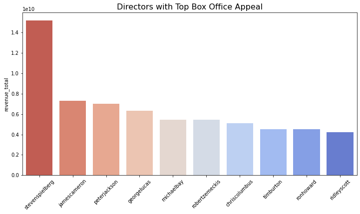

```python
plt.figure(figsize=(12,6))
plt.title('Directors with Top Box Office Appeal', fontsize=16)

sns.barplot(x=df_dir.sort_values(by='revenue_total',ascending=False)[:10].index,y='revenue_total',data=df_dir.sort_values(by='revenue_total',ascending=False)[:10],palette='coolwarm_r')
plt.xlabel('')
plt.xticks(rotation=45)
```

It shows that the top 10 directors with the greatest revenue generation ability are Steven Spielberg, James Cameron, Peter Jackson, George Lucas, Michael Bay, Robert Zemeckis, Chris Columbus, Tim Burton, Ron Howard, and Ridley Scott. Steven Spielberg's movies made a lot more money than the other directors'.

#### Q2.6 Who are the 10 most revenue-generating actors/actresses over 1960-2015?

Previously I extracted 3 main cast for each movie, so here I will apply the similar processing on the cast column that I did to genres column.

```python
# create a sub-dataframe containing only columns release_year, genres and revenue_adj. Column revenue_adj is for later use
df_cast = movie_df[['release_year','cast','revenue_adj']]

# create separate column for each genre value
df_cast['cast1'] = df_cast['cast'].apply(lambda x: x[0])
df_cast['cast2'] = df_cast['cast'].apply(lambda x: x[1] if len(x)>1 else None)
df_cast['cast3'] = df_cast['cast'].apply(lambda x: x[2] if len(x)>2 else None)
# remove original column genres, and melt 4-column dataframe into 2-column dataframe
df_cast = df_cast.drop('cast',axis=1).melt(['release_year','revenue_adj']).drop('variable',axis=1).rename(columns={'value':'cast'})
df_cast.head(3)
```

|  | release_year | revenue_adj | cast |
| --- | --- | --- | --- |
| 0 | 2015 | 1.392446e+09 | chrispratt |
| 1 | 2015 | 3.481613e+08 | tomhardy |
| 2 | 2015 | 2.716190e+08 | shailenewoodley |

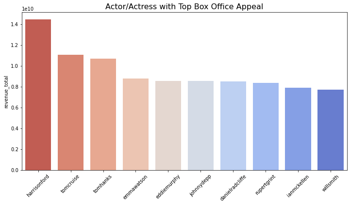

```python
df_cast = df_cast.drop('release_year',axis=1).groupby('cast')['revenue_adj'].agg([('revenue_avg','mean'),('revenue_total','sum')])

plt.figure(figsize=(12,6))
plt.title('Actor/Actress with Top Box Office Appeal', fontsize=16)

sns.barplot(x=df_cast.sort_values(by='revenue_total',ascending=False)[:10].index,y='revenue_total',data=df_cast.sort_values(by='revenue_total',ascending=False)[:10],palette='coolwarm_r')
plt.xlabel('')
plt.xticks(rotation=45)
```

From the above chart we can tell that the actors/actresses with the greatest box office appeal are Harrison Ford, Tom Cruise, Tom Hanks, Emma Watson, Eddie Murphy, Johnny Depp, Daniel Radcliffe, Rupert Grint, Ian McKellen, and Will Smith.

## Conclusion

### Summary of Findings

#### For genres popularity:

- The five most popular genres are action, comedy, drama, horror, and thriller over all years.
- When it comes down to each decade, drama has always been the winner among all genres, except in 1980s when comedy took over and became the most popular genre.

### Potential Improvement

Additionally I could take logarithm values of revenue and budget when studying the correlation between various numeric features and revenue, so the charts will be easier to interpret.

One more thing I could have done is add a new feature to calculate the profitability of each movie (i.e., (revenue - budget) / budget). I could research questions like what genres tend to generate higher return on investment, how profitability has changed year from year. et cetera.

## Submitting Project

```python
from subprocess import call
call(['python', '-m', 'nbconvert', 'Investigate_a_Dataset.ipynb'])
```

```
255
```